# Portfolio assignment 9

Perform a bivariate analysis on the columns with numerical data in the penguins dataset.

- Use corr() on the DataFrame to calculate all the correlations.
- Look at the corrrelations. Do they match your expectations?
- Show a scatter plot for
  - The strongest positive correlation
  - The strongest negative correlation
  - The weakest correlation

```python
import pandas as pd
pd.options.mode.chained_assignment = None

import seaborn as sns
```

```python
data = sns.load_dataset('penguins')
data.shape
```

```
(344, 7)
```

## Correlations

```python
datacorr = data.corr()
datacorr.style.background_gradient(cmap='coolwarm', axis=None).format(precision=2)
```

|  | bill_length_mm | bill_depth_mm | flipper_length_mm | body_mass_g |
| --- | --- | --- | --- | --- |
| bill_length_mm | 1.00 | -0.24 | 0.66 | 0.60 |
| bill_depth_mm | -0.24 | 1.00 | -0.58 | -0.47 |
| flipper_length_mm | 0.66 | -0.58 | 1.00 | 0.87 |
| body_mass_g | 0.60 | -0.47 | 0.87 | 1.00 |

There is strong positive correlation between Flipper_Length and Body_Mass. This is obvious because a big penguin needs big flippers to swim.

A negative correlation shows between Flipper_Length and Bill_Depth. So a penguin with a longer flipper has, according to these number, a smaller sized beak.

## Scatterplots

### Strong positive correlation: flipper_length & body_mass

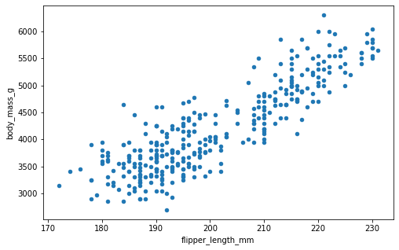

```python
data.plot(kind='scatter', x='flipper_length_mm', y='body_mass_g', figsize=(8, 5))
```

Bigger penguins have longer flippers, no surprises here.

### Strong negative correlation: flipper_length & bill_depth

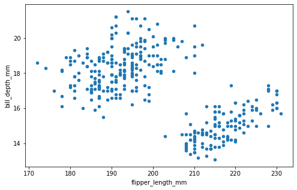

```python
data.plot(kind='scatter', x='flipper_length_mm', y='bill_depth_mm', figsize=(8, 5))
```

There is a negative correlation, but this plot is more interesting. There are two clouds visible and I think it's the division between two penguin species. One species with a big beak and short flippers, and another with a smaller beak and long flippers.

### Weak correlation: bill_length & bill_depth

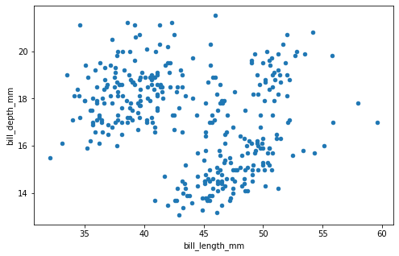

```python
data.plot(kind='scatter', x='bill_length_mm', y='bill_depth_mm', figsize=(8, 5))
```